# COVID deaths and Joe Biden

Kiran Bhattacharyya

2/20/2021

## Did the deaths due to COVID-19 influence Joe Biden’s election?

Here, I look at COVID-19 deaths by county in the USA and try to understand how it may have influenced the 2020 US Presidential election. Alongside COVID-19 deaths, I also look at other demographics of the population in the county like racial composition, educational attainment, median income, and unemployment rates. The population demographics data are from 2019. The COVID-19 deaths reported here are aggregates from Feb 1, 2020 to Oct 17,2020. This specific range was selected since it was the range of time available for the data that was immediately preceding the election on Nov 6, 2020. All associated code and data for this project can be found in this GitHub repo: https://github.com/MiningMyBusiness/covid_and_biden

I must note here that the data was created by merging together disparate data sets which are all openly available for download from different US government agencies. There is a description of where to find these data sets and the code for how they were merged here: https://github.com/MiningMyBusiness/covid_and_biden/tree/main/raw_data

```r
# read in covid data
covid_data <- readRDS('covid_data_combo_by_county.rds')

covid_data <- mutate(covid_data,
                     high.school.or.below = Percent.of.adults.with.less.than.a.high.school.diploma.2014_18 + Percent.of.adults.with.a.high.school.diploma.only.2014_18,
                     some.college.or.above = Percent.of.adults.completing.some.college.or.associates.degree.2014_18 + Percent.of.adults.with.a.bachelors.degree.or.higher.2014_18)

names(covid_data)
```

```
##  [1] "Data.as.of"
##  [2] "StartWeek"
##  [3] "EndWeek"
##  [4] "State"
##  [5] "County"
##  [6] "Fips.Code"
##  [7] "COVID19.Deaths"
##  [8] "Total.Deaths"
##  [9] "covid_death_prop"
## [10] "POP_ESTIMATE_2019"
## [11] "medium_income"
## [12] "unem_rate"
## [13] "Less.than.a.high.school.diploma.2014_18"
## [14] "High.school.diploma.only.2014_18"
## [15] "Some.college.or.associates.degree.2014_18"
```

[output cut: 33 more lines]

Above we load in the data, do a little processing, and print out the column names. The column names are mostly self-explanatory.

### Total COVID deaths, proportion of deaths due to COVID, and Biden’s victory

Let’s start by looking at the total number of COVID deaths, the proportion of covid deaths, and whether Joe Biden won by county.

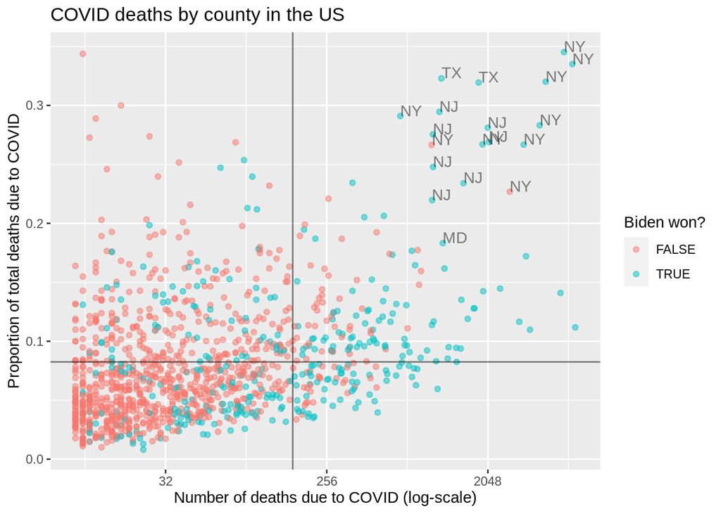

```r
ggplot(data=covid_data) +
  geom_point(mapping=aes(x=COVID19.Deaths,
                         y=covid_death_prop,
                         color=won),
                                     alpha=0.5) +
  scale_x_continuous(trans='log2') +
  geom_hline(yintercept=mean(covid_data$covid_death_prop),
             alpha=0.5) +
  geom_vline(xintercept=mean(covid_data$COVID19.Deaths),
             alpha=0.5) +
  geom_text(data=filter(covid_data,
                        covid_death_prop > quantile(covid_death_prop, 0.95),
                        COVID19.Deaths > quantile(COVID19.Deaths, 0.95)),
            mapping=aes(x=COVID19.Deaths,y=covid_death_prop,
                        label=State), hjust=0, vjust=0,
            alpha=0.5) +
  labs(x='Number of deaths due to COVID (log-scale)',
       y="Proportion of total deaths due to COVID",
       title="COVID deaths by county in the US",
       color="Biden won?")
```

It looks as if Joe Biden got the majority of votes in the counties that had larger numbers of deaths due to COVID19. However, it isn’t clear if he won in counties that had larger proportion of total deaths due to COVID. This could just imply that Biden tended to win in counties with larger populations and these counties also had larger numbers of deaths due to COVID19 (due to their bigger population).

Let’s look at how the proportion of deaths due to COVID relates to the population.

### Proportion of deaths due to COVID, population, and Biden’s victory

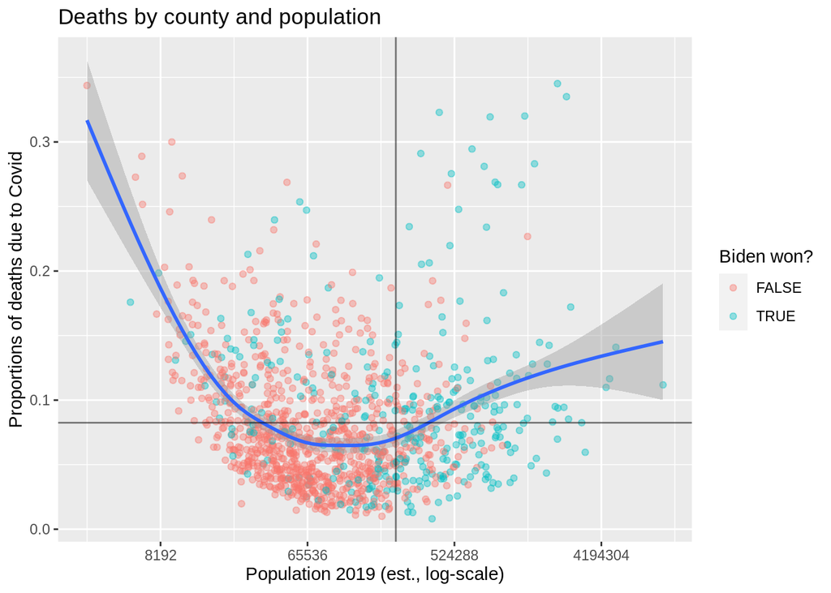

```r
ggplot(data=covid_data) + geom_point(mapping=aes(y=covid_death_prop,
                                                 x=POP_ESTIMATE_2019,
                                                 color=won),
                                     alpha=0.4) +
  geom_smooth(mapping=aes(y=covid_death_prop, x=POP_ESTIMATE_2019)) +
  scale_x_continuous(trans='log2') +
  geom_hline(yintercept=mean(covid_data$covid_death_prop),
             alpha=0.5) +
  geom_vline(xintercept=mean(covid_data$POP_ESTIMATE_2019),
             alpha=0.5) +
  labs(y="Proportions of deaths due to Covid",
       x="Population 2019 (est., log-scale)",
       title="Deaths by county and population",
       color="Biden won?")
```

So it looks clear that Biden was more likely to win in counties with larger populations, regardless of the proportion of deaths due to COVID. However, it does seem like Biden was more likely to win in counties with smaller populations which also had larger proportion of deaths due to COVID. However, still less likely to win in counties with smaller populations overall than Trump.

Let’s look at this data another way.

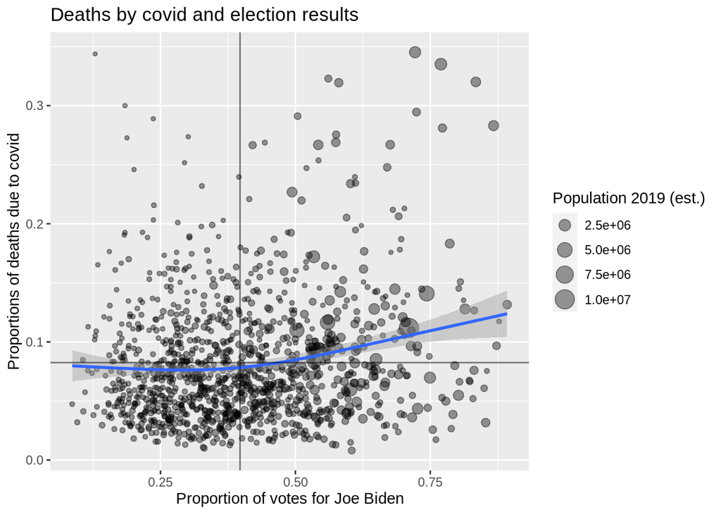

```r
ggplot(data=covid_data) + geom_point(mapping=aes(y=covid_death_prop,
                                                 x=prop_biden_votes,
                                                 size=POP_ESTIMATE_2019),
                                     alpha=0.4) +
  geom_smooth(mapping=aes(y=covid_death_prop,
                          x=prop_biden_votes)) +
  geom_hline(yintercept=mean(covid_data$covid_death_prop),
             alpha=0.5) +
  geom_vline(xintercept=mean(covid_data$prop_biden_votes),
             alpha=0.5) +
  labs(y="Proportions of deaths due to covid",
       x="Proportion of votes for Joe Biden",
       title="Deaths by covid and election results",
       size="Population 2019 (est.)")
```

So it looks like Biden won in counties with larger populations and those with a larger proportion of deaths due to COVID. However, there are a lot of features of the demographics of these counties that could also effect the result of the 2020 Presidential election in the US.

Let’s take a closer look at other features of the counties like income, education, race, and unemployment.

### Proportion of White population, proportion of deaths due to COVID, and votes for Biden

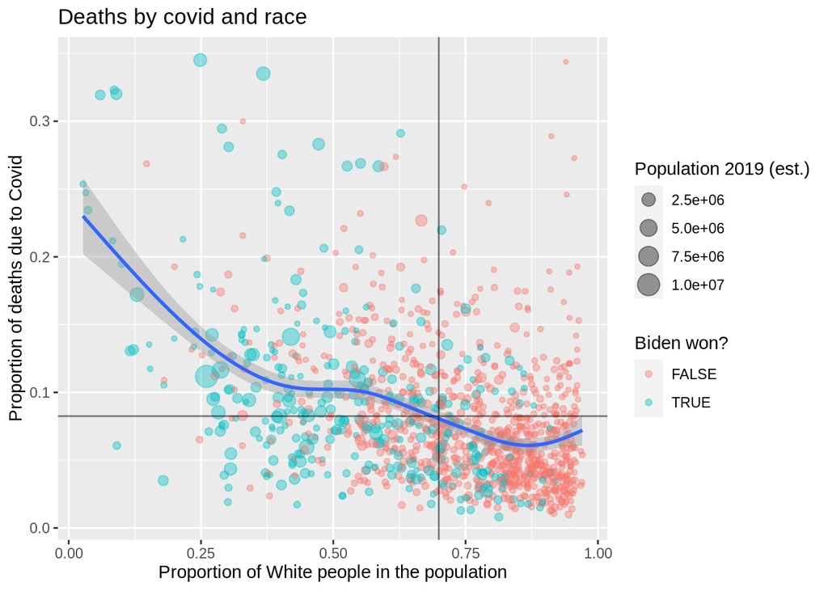

```r
ggplot(data=covid_data) + geom_point(mapping=aes(size=POP_ESTIMATE_2019,
                                                 x=prop_white,
                                                 y=covid_death_prop,
                                                 color=won),
                                     alpha=0.4) +
  geom_smooth(mapping=aes(y=covid_death_prop,
                          x=prop_white)) +
  geom_hline(yintercept=mean(covid_data$covid_death_prop),
             alpha=0.5) +
  geom_vline(xintercept=mean(covid_data$prop_white),
             alpha=0.5) +
  labs(y="Proportion of deaths due to Covid",
       x="Proportion of White people in the population",
       title="Deaths by covid and race",
       color="Biden won?",
       size="Population 2019 (est.)")
```

Joe Biden mostly lost in counties with majority white populations and small overall populations. However, the proportion of deaths due to COVID-19 was also lower for these counties.

Since White, Black, and Hispanic are the largest racial categories in the US, similar graphs with different x-axis labels for Black and Hispanic people show an opposite trend (as larger proportions of White people suggest smaller proportions of Black and Hispanic people and vice versa). But, it’s still worth visualizing.

### Proportion of Black population, proportion of deaths due to COVID, and votes for Biden

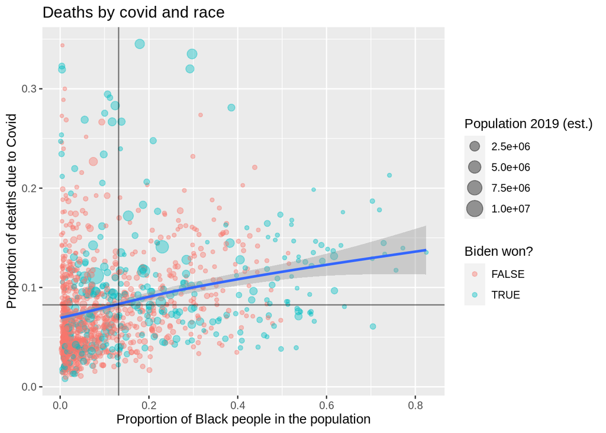

```r
ggplot(data=covid_data) + geom_point(mapping=aes(size=POP_ESTIMATE_2019,
                                                 x=prop_black,
                                                 y=covid_death_prop,
                                                 color=won),
                                     alpha=0.4) +
  geom_smooth(mapping=aes(y=covid_death_prop,
                          x=prop_black)) +
  geom_hline(yintercept=mean(covid_data$covid_death_prop),
             alpha=0.5) +
  geom_vline(xintercept=mean(covid_data$prop_black),
             alpha=0.5) +
  labs(y="Proportion of deaths due to Covid",
       x="Proportion of Black people in the population",
       title="Deaths by covid and race",
       color="Biden won?",
       size="Population 2019 (est.)")
```

### Proportion of Hispanic population, proportion of deaths due to COVID, and votes for Biden

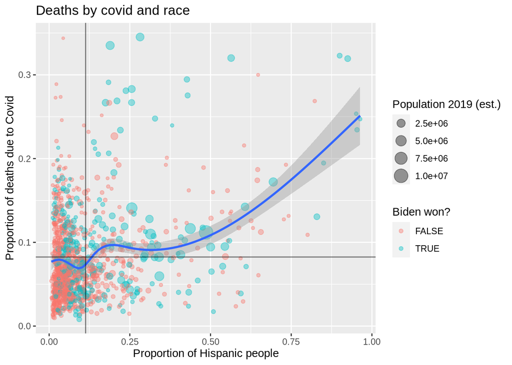

```r
ggplot(data=covid_data) + geom_point(mapping=aes(size=POP_ESTIMATE_2019,
                                                 x=prop_hisp,
                                                 y=covid_death_prop,
                                                 color=won),
                                     alpha=0.4) +
  geom_smooth(mapping=aes(y=covid_death_prop,
                          x=prop_hisp)) +
  geom_hline(yintercept=mean(covid_data$covid_death_prop),
             alpha=0.5) +
  geom_vline(xintercept=mean(covid_data$prop_hisp),
             alpha=0.5) +
  labs(y="Proportion of deaths due to Covid",
       x="Proportion of Hispanic people",
       title="Deaths by covid and race",
       color="Biden won?",
       size="Population 2019 (est.)")
```

Proportions of deaths due to COVID-19 were larger for counties with larger Black and Hispanic populations.